# carrerfour_analysis

Bill

11/13/2020

# 1. Problem Definition

## 1.1 Defining the Question

As a Data analyst at Carrefour Kenya,I have been consulted to undertake a project that will inform the marketing department on the most relevant marketing strategies that will result in the highest no. of sales (total price including tax). My project will explore a recent marketing dataset provided by performing various unsupervised learning techniques and later providing recommendations based on my insights.

## 1.2 Specifying the Question

I am expected to check whether there are any anomalies in the given sales dataset. The objective of this task being fraud detection.

## 1.4 Understanding the Context

Carrefour, one of the largest hypermarket chains in the world was introduced to the Middle East and North Africa (MENA) market in 1995 by Majid Al Futtaim, the leading shopping mall, retail and leisure pioneer across MENA.

Carrefour has become the most dynamic, fast-moving and exciting hypermarket chain in the region and shared its growth with more than 38,000 employees from more than 70 nationalities in 15 countries, providing shoppers with variety and value-for-money.

Carrefour ensures customer satisfaction and everyday convenience while offering unbeatable value for money with a vast array of more than 100,000 products, shoppers can purchase items for their every need, whether home electronics or fresh fruits from around the world, to locally produced items.

Carrefour opened its first outlet in Kenya in 2016, and currently operates over 250 hypermarkets, supermarkets, and online stores in 15 countries across the region, with plans to extend into 38 countries in the Middle East, Central Asia, Africa and Russia.

Carrefour always strive to provide the best quality and most diverse selection of household goods available in Kenya. Our value packs and combination discount offers means that we can offer these products at even lower costs, keeping your household essentials at unbeatable prices.

## 1.5 Experimental Design taken

```r
# Load tidyverse and anomalize
# ---
#
# load libraries
library(tidyverse)
library(tibbletime)
library(anomalize)
library(readr)
```

```r
Supermarket_Sales_Forecasting_Sales <- read_csv("datasets/Supermarket_Sales_Forecasting - Sales.csv")
## previewing first 6 rows
head(Supermarket_Sales_Forecasting_Sales)
```

```
## # A tibble: 6 x 2
##   Date      Sales
##   <chr>     <dbl>
## 1 1/5/2019  549.
## 2 3/8/2019   80.2
## 3 3/3/2019  341.
## 4 1/27/2019 489.
## 5 2/8/2019  634.
## 6 3/25/2019 628.
```

```r
##previewing the last 6 rows of the dataset
tail(Supermarket_Sales_Forecasting_Sales)
```

```
## # A tibble: 6 x 2
##   Date       Sales
##   <chr>      <dbl>
## 1 2/18/2019   64.0
## 2 1/29/2019   42.4
## 3 3/2/2019  1022.
## 4 2/9/2019    33.4
## 5 2/22/2019   69.1
## 6 2/18/2019  649.
```

```r
## Previewing the shape of our dataset
dim(Supermarket_Sales_Forecasting_Sales)
```

```
## [1] 1000    2
```

```r
### we have 1000  rows and 2 columns!!!BAM!!

#checking the datatypes on the columns
sapply(Supermarket_Sales_Forecasting_Sales, class)
```

```
##        Date       Sales
## "character"   "numeric"
```

```r
## the datecolumn is in character form,,, will need to convert it to datetime
Supermarket_Sales_Forecasting_Sales$Date <- anytime::anydate(Supermarket_Sales_Forecasting_Sales$Date)

str(Supermarket_Sales_Forecasting_Sales)
```

```
## tibble [1,000 x 2] (S3: spec_tbl_df/tbl_df/tbl/data.frame)
##  $ Date : Date[1:1000], format: "2019-01-05" "2019-03-08" ...
##  $ Sales: num [1:1000] 549 80.2 340.5 489 634.4 ...
##  - attr(*, "spec")=
##   .. cols(
##   ..   Date = col_character(),
##   ..   Sales = col_double()
##   .. )
```

```r
## We then a statistical summary of our dataset

summary(Supermarket_Sales_Forecasting_Sales)
```

```
##       Date                Sales
##  Min.   :2019-01-01   Min.   :  10.68
##  1st Qu.:2019-01-24   1st Qu.: 124.42
##  Median :2019-02-13   Median : 253.85
##  Mean   :2019-02-14   Mean   : 322.97
##  3rd Qu.:2019-03-08   3rd Qu.: 471.35
##  Max.   :2019-03-30   Max.   :1042.65
```

Extract the year, month and day from the date column

```r
Supermarket_Sales_Forecasting_Sales$year <- as.numeric(format(Supermarket_Sales_Forecasting_Sales$Date, format="%Y"))
Supermarket_Sales_Forecasting_Sales$month <- as.numeric(format(Supermarket_Sales_Forecasting_Sales$Date, format="%m"))
Supermarket_Sales_Forecasting_Sales$day <- as.numeric(format(Supermarket_Sales_Forecasting_Sales$Date, format="%d"))
#check the datatypes
head(Supermarket_Sales_Forecasting_Sales)
```

```
## # A tibble: 6 x 5
##   Date       Sales  year month   day
##   <date>     <dbl> <dbl> <dbl> <dbl>
## 1 2019-01-05 549.   2019     1     5
## 2 2019-03-08  80.2  2019     3     8
## 3 2019-03-03 341.   2019     3     3
## 4 2019-01-27 489.   2019     1    27
## 5 2019-02-08 634.   2019     2     8
## 6 2019-03-25 628.   2019     3    25
```

## To ensure uniformity, I will lowercase all the columns

```r
names(Supermarket_Sales_Forecasting_Sales)<- tolower(names(Supermarket_Sales_Forecasting_Sales))
head(Supermarket_Sales_Forecasting_Sales)
```

```
## # A tibble: 6 x 5
##   date       sales  year month   day
##   <date>     <dbl> <dbl> <dbl> <dbl>
## 1 2019-01-05 549.   2019     1     5
## 2 2019-03-08  80.2  2019     3     8
## 3 2019-03-03 341.   2019     3     3
## 4 2019-01-27 489.   2019     1    27
## 5 2019-02-08 634.   2019     2     8
## 6 2019-03-25 628.   2019     3    25
```

```r
##Checking for missing values in each row
colSums(is.na(Supermarket_Sales_Forecasting_Sales))
```

```
##  date sales  year month   day
##     0     0     0     0     0
```

```r
anyDuplicated(Supermarket_Sales_Forecasting_Sales)
```

```
## [1] 0
```

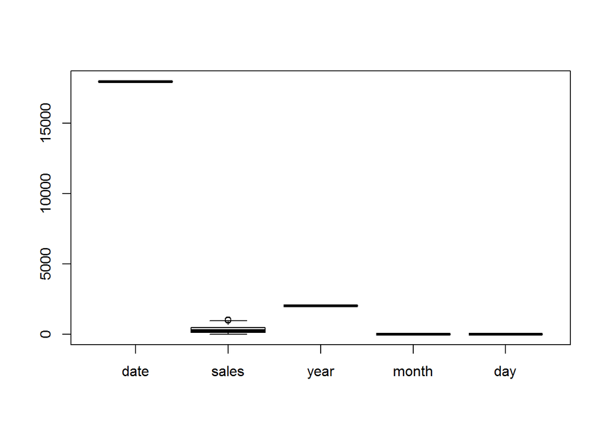

```r
# Checking for Outliers in Sales column
boxplot(Supermarket_Sales_Forecasting_Sales)
```

##EDA

```r
## finding the summary statistic of our time series dataset
summary(Supermarket_Sales_Forecasting_Sales)
```

```
##       date                sales              year          month
##  Min.   :2019-01-01   Min.   :  10.68   Min.   :2019   Min.   :1.000
##  1st Qu.:2019-01-24   1st Qu.: 124.42   1st Qu.:2019   1st Qu.:1.000
##  Median :2019-02-13   Median : 253.85   Median :2019   Median :2.000
##  Mean   :2019-02-14   Mean   : 322.97   Mean   :2019   Mean   :1.993
##  3rd Qu.:2019-03-08   3rd Qu.: 471.35   3rd Qu.:2019   3rd Qu.:3.000
##  Max.   :2019-03-30   Max.   :1042.65   Max.   :2019   Max.   :3.000
##       day
##  Min.   : 1.00
##  1st Qu.: 8.00
##  Median :15.00
##  Mean   :15.26
##  3rd Qu.:23.00
##  Max.   :31.00
```

```r
# Correlations
correlations <- cor(Supermarket_Sales_Forecasting_Sales[,2:3], method = "pearson")
round(correlations, 2)
```

```
##       sales year
## sales     1   NA
## year     NA    1
```